# Colorectal Cancer Risk & Survival — Exploratory Data Analysis

## Project Overview

This project performs an exploratory data analysis of a colorectal cancer patient dataset.

The analysis focuses on understanding patterns and relationships among:

- Demographic characteristics
- Lifestyle and dietary factors
- Family and previous cancer history
- Cancer stage and tumor aggressiveness
- Screening and healthcare access
- Treatment-related factors
- Survival status
- Recurrence patterns

The goal is to generate meaningful, data-driven insights from the dataset rather than build a machine learning prediction model.

## 1. Project Objectives

The main objectives of this analysis are to:

1. Understand the structure and characteristics of the dataset.
2. Assess data quality, including missing values and duplicate records.
3. Explore demographic and clinical characteristics of patients.
4. Analyze lifestyle and potential risk-related factors.
5. Examine survival patterns across different patient groups.
6. Investigate the relationship between cancer stage, tumor aggressiveness, treatment, and survival.
7. Analyze recurrence patterns among patients.
8. Identify important patterns and relationships using statistical summaries and visualizations.
9. Present actionable insights and conclusions from the analysis.

> **Note:** This is an exploratory and descriptive data analysis project. Observed relationships should not be interpreted as causal or as medical advice.

## 2. Dataset Overview

The dataset contains patient-level records related to colorectal cancer.

### Main categories of variables

**Demographic Variables**

- Age
- Gender
- Race
- Region
- Urban/Rural status
- Socioeconomic status

**Risk and Lifestyle Variables**

- Family history
- Previous cancer history
- Diet type
- BMI
- Physical activity
- Smoking
- Alcohol consumption
- Red meat consumption
- Fiber consumption

**Clinical Variables**

- Stage at diagnosis
- Tumor aggressiveness
- Time to diagnosis

**Healthcare and Treatment Variables**

- Colonoscopy access
- Screening regularity
- Insurance coverage
- Treatment access
- Chemotherapy
- Radiotherapy
- Surgery
- Follow-up adherence

**Outcome Variables**

- Survival status
- Recurrence
- Time to recurrence

## Analysis Workflow

**Dataset → Data Quality → Exploratory Analysis → Demographic Analysis → Clinical Analysis → Lifestyle Analysis → Healthcare & Treatment Analysis → Recurrence Analysis → Correlation Analysis → Key Findings → Conclusion**

This notebook is focused on descriptive and exploratory data analysis. No machine-learning prediction model is used.

### 3. Import Libraries

```python
# Import required libraries

import pandas as pd
import numpy as np
import matplotlib.pyplot as plt
import seaborn as sns

# Display settings
pd.set_option("display.max_columns", None)
pd.set_option("display.max_rows", 100)

# Visualization style
sns.set_theme(style="whitegrid")

print("Libraries imported successfully.")
```

```
Libraries imported successfully.
```

## 4. Dataset Loading

The dataset contains patient-level information covering demographic, lifestyle, clinical, treatment, healthcare-access, survival, and recurrence characteristics.

```python
# Load the dataset

df = pd.read_csv("colorectal_cancer_prediction.csv")

print("Dataset loaded successfully.")
print(f"Rows: {df.shape[0]:,}")
print(f"Columns: {df.shape[1]}")

display(df.head())


# Basic dataset information

print("Dataset Shape:", df.shape)

print("\nColumn Names:")
print(df.columns.tolist())

print("\nData Types:")
display(df.dtypes)

print("\nDataset Information:")
df.info()
```

```
Dataset loaded successfully.
Rows: 89,945
Columns: 30
```

|  | Patient_ID | Age | Gender | Race | Region | Urban_or_Rural | Socioeconomic_Status | Family_History | Previous_Cancer_History | Stage_at_Diagnosis | Tumor_Aggressiveness | Colonoscopy_Access | Screening_Regularity | Diet_Type | BMI | Physical_Activity_Level | Smoking_Status | Alcohol_Consumption | Red_Meat_Consumption | Fiber_Consumption | Insurance_Coverage | Time_to_Diagnosis | Treatment_Access | Chemotherapy_Received | Radiotherapy_Received | Surgery_Received | Follow_Up_Adherence | Survival_Status | Recurrence | … |
| --- | --- | --- | --- | --- | --- | --- | --- | --- | --- | --- | --- | --- | --- | --- | --- | --- | --- | --- | --- | --- | --- | --- | --- | --- | --- | --- | --- | --- | --- | --- |
| 0 | 1 | 71 | Male | Other | Europe | Urban | Middle | Yes | No | III | High | No | Regular | Western | 33.0 | Low | Never | Low | Low | Low | Yes | Delayed | Good | Yes | No | No | Good | Survived | No | … |
| 1 | 2 | 34 | Female | Black | North America | Urban | Middle | No | No | I | Medium | Yes | Regular | Western | 33.1 | Medium | Never | Low | Low | Low | No | Timely | Good | No | Yes | Yes | Poor | Deceased | No | … |
| 2 | 3 | 80 | Female | White | North America | Urban | Middle | No | No | III | Low | Yes | Regular | Balanced | 20.7 | Medium | Never | Low | Low | Medium | Yes | Timely | Limited | No | Yes | Yes | Good | Survived | No | … |
| 3 | 4 | 40 | Male | Black | North America | Rural | Low | No | No | I | Medium | Yes | Never | Traditional | 38.9 | Medium | Former | Low | Low | High | Yes | Delayed | Limited | Yes | No | Yes | Poor | Deceased | No | … |
| 4 | 5 | 43 | Female | White | Europe | Urban | High | Yes | No | III | Low | Yes | Never | Traditional | 24.8 | Medium | Former | High | Medium | Low | No | Delayed | Good | Yes | No | Yes | Poor | Deceased | Yes | … |

```
Dataset Shape: (89945, 30)

Column Names:
['Patient_ID', 'Age', 'Gender', 'Race', 'Region', 'Urban_or_Rural', 'Socioeconomic_Status', 'Family_History', 'Previous_Cancer_History', 'Stage_at_Diagnosis', 'Tumor_Aggressiveness', 'Colonoscopy_Access', 'Screening_Regularity', 'Diet_Type', 'BMI', 'Physical_Activity_Level', 'Smoking_Status', 'Alcoh…

Data Types:
```

```
Patient_ID                   int64
Age                          int64
Gender                         str
Race                           str
Region                         str
Urban_or_Rural                 str
Socioeconomic_Status           str
Family_History                 str
Previous_Cancer_History        str
Stage_at_Diagnosis             str
Tumor_Aggressiveness           str
Colonoscopy_Access             str
Screening_Regularity           str
Diet_Type                      str
BMI                        float64
Physical_Activity_Level        str
Smoking_Status                 str
Alcohol_Consumption            str
Red_Meat_Consumption           str
Fiber_Consumption              str
Insurance_Coverage             str
Time_to_Diagnosis              str
Treatment_Access               str
Chemotherapy_Received          str
Radiotherapy_Received          str
Surgery_Received               str
Follow_Up_Adherence            str
Survival_Status                str
Recurrence                     str
Time_to_Recurrence           int64
dtype: object
```

```
Dataset Information:
<class 'pandas.DataFrame'>
RangeIndex: 89945 entries, 0 to 89944
Data columns (total 30 columns):
 #   Column                   Non-Null Count  Dtype
---  ------                   --------------  -----
 0   Patient_ID               89945 non-null  int64
 1   Age                      89945 non-null  int64
 2   Gender                   89945 non-null  str
 3   Race                     89945 non-null  str
 4   Region                   89945 non-null  str
 5   Urban_or_Rural           89945 non-null  str
 6   Socioeconomic_Status     89945 non-null  str
 7   Family_History           89945 non-null  str
 8   Previous_Cancer_History  89945 non-null  str
```

[output cut: 23 more lines]

# 5.Exploratory Data Analysis (EDA)

Exploratory Data Analysis is performed to understand the distribution, composition, and relationships within the patient dataset.

## Data Quality Assessment

Before performing exploratory analysis, the dataset is checked for:

- Missing values
- Duplicate records
- Duplicate patient IDs
- Incorrect or unexpected data types
- Basic numerical summaries
- Categorical value distributions

|  | Missing Values | Missing Percentage |
| --- | --- | --- |
| Patient_ID | 0 | 0.0 |
| Age | 0 | 0.0 |
| Gender | 0 | 0.0 |
| Race | 0 | 0.0 |
| Region | 0 | 0.0 |
| Urban_or_Rural | 0 | 0.0 |
| Socioeconomic_Status | 0 | 0.0 |
| Family_History | 0 | 0.0 |
| Previous_Cancer_History | 0 | 0.0 |
| Stage_at_Diagnosis | 0 | 0.0 |
| Tumor_Aggressiveness | 0 | 0.0 |
| Colonoscopy_Access | 0 | 0.0 |
| Screening_Regularity | 0 | 0.0 |
| Diet_Type | 0 | 0.0 |
| BMI | 0 | 0.0 |
| Physical_Activity_Level | 0 | 0.0 |
| Smoking_Status | 0 | 0.0 |
| Alcohol_Consumption | 0 | 0.0 |
| Red_Meat_Consumption | 0 | 0.0 |
| Fiber_Consumption | 0 | 0.0 |
| Insurance_Coverage | 0 | 0.0 |
| Time_to_Diagnosis | 0 | 0.0 |
| Treatment_Access | 0 | 0.0 |
| Chemotherapy_Received | 0 | 0.0 |
| Radiotherapy_Received | 0 | 0.0 |
| Surgery_Received | 0 | 0.0 |
| Follow_Up_Adherence | 0 | 0.0 |
| Survival_Status | 0 | 0.0 |
| Recurrence | 0 | 0.0 |
| Time_to_Recurrence | 0 | 0.0 |

```
Total missing values: 0
Duplicate rows: 0
Duplicate Patient IDs: 0

Data quality check: No duplicate records or duplicate patient IDs found.
```

|  | Column | Unique Values |
| --- | --- | --- |
| 0 | Gender | 2 |
| 1 | Race | 5 |
| 2 | Region | 5 |
| 3 | Urban_or_Rural | 2 |
| 4 | Socioeconomic_Status | 3 |
| 5 | Family_History | 2 |
| 6 | Previous_Cancer_History | 2 |
| 7 | Stage_at_Diagnosis | 4 |
| 8 | Tumor_Aggressiveness | 3 |
| 9 | Colonoscopy_Access | 2 |
| 10 | Screening_Regularity | 3 |
| 11 | Diet_Type | 3 |
| 12 | Physical_Activity_Level | 3 |
| 13 | Smoking_Status | 3 |
| 14 | Alcohol_Consumption | 3 |
| 15 | Red_Meat_Consumption | 3 |
| 16 | Fiber_Consumption | 3 |
| 17 | Insurance_Coverage | 2 |
| 18 | Time_to_Diagnosis | 2 |
| 19 | Treatment_Access | 2 |
| 20 | Chemotherapy_Received | 2 |
| 21 | Radiotherapy_Received | 2 |
| 22 | Surgery_Received | 2 |
| 23 | Follow_Up_Adherence | 2 |
| 24 | Survival_Status | 2 |
| 25 | Recurrence | 2 |

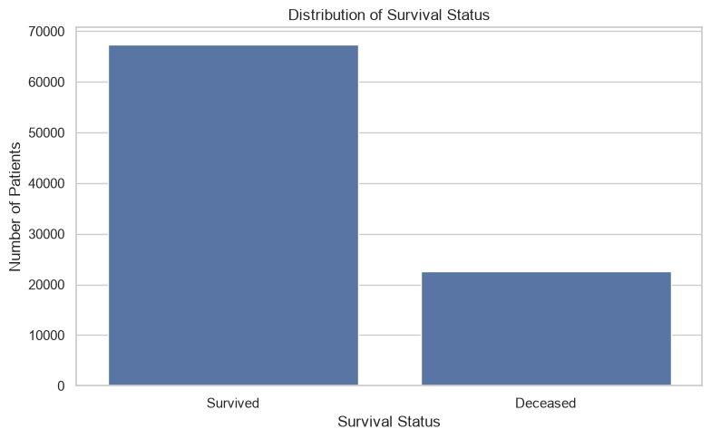

| Survival_Status | Count | Percentage |
| --- | --- | --- |
| Survived | 67341 | 74.87 |
| Deceased | 22604 | 25.13 |

```python
# Check for missing values

missing_values = df.isnull().sum()

missing_summary = pd.DataFrame({
    "Missing Values": missing_values,
    "Missing Percentage": (missing_values / len(df) * 100).round(2)
})

display(missing_summary)

print("Total missing values:", df.isnull().sum().sum())

# Check for duplicate records and duplicate patient IDs

duplicate_rows = df.duplicated().sum()
duplicate_patient_ids = df["Patient_ID"].duplicated().sum()

print("Duplicate rows:", duplicate_rows)
print("Duplicate Patient IDs:", duplicate_patient_ids)

if duplicate_rows == 0 and duplicate_patient_ids == 0:
    print("\nData quality check: No duplicate records or duplicate patient IDs found.")


# Categorical variable summary

categorical_columns = df.select_dtypes(include="object").columns

categorical_summary = pd.DataFrame({
    "Column": categorical_columns,
    "Unique Values": [df[col].nunique() for col in categorical_columns]
})

display(categorical_summary)

# Visualize Survival Status Distribution

plt.figure(figsize=(8, 5))

sns.countplot(
    data=df,
    x="Survival_Status"
)

plt.title("Distribution of Survival Status")
plt.xlabel("Survival Status")
plt.ylabel("Number of Patients")

plt.tight_layout()
plt.show()

# Survival Status Summary

survival_summary = pd.DataFrame({
    "Count": df["Survival_Status"].value_counts(),
    "Percentage": (
        df["Survival_Status"]
        .value_counts(normalize=True)
        .mul(100)
        .round(2)
    )
})

display(survival_summary)
```

## 6. Data Preparation for Analysis

The dataset does not require machine-learning preprocessing because this project focuses on exploratory and descriptive analysis.

The `Patient_ID` column is an identifier and will not be used for statistical comparisons or visualizations.

No train-test split, feature encoding, normalization, or model-specific preprocessing is required.

```python
# Create a clean analysis copy

analysis_df = df.copy()

# Patient_ID is an identifier, not an analytical feature
analysis_df = analysis_df.drop(columns=["Patient_ID"])

print("Analysis dataset shape:", analysis_df.shape)
display(analysis_df.head())
```

```
Analysis dataset shape: (89945, 29)
```

|  | Age | Gender | Race | Region | Urban_or_Rural | Socioeconomic_Status | Family_History | Previous_Cancer_History | Stage_at_Diagnosis | Tumor_Aggressiveness | Colonoscopy_Access | Screening_Regularity | Diet_Type | BMI | Physical_Activity_Level | Smoking_Status | Alcohol_Consumption | Red_Meat_Consumption | Fiber_Consumption | Insurance_Coverage | Time_to_Diagnosis | Treatment_Access | Chemotherapy_Received | Radiotherapy_Received | Surgery_Received | Follow_Up_Adherence | Survival_Status | Recurrence | Time_to_Recurrence |
| --- | --- | --- | --- | --- | --- | --- | --- | --- | --- | --- | --- | --- | --- | --- | --- | --- | --- | --- | --- | --- | --- | --- | --- | --- | --- | --- | --- | --- | --- |
| 0 | 71 | Male | Other | Europe | Urban | Middle | Yes | No | III | High | No | Regular | Western | 33.0 | Low | Never | Low | Low | Low | Yes | Delayed | Good | Yes | No | No | Good | Survived | No | 16 |
| 1 | 34 | Female | Black | North America | Urban | Middle | No | No | I | Medium | Yes | Regular | Western | 33.1 | Medium | Never | Low | Low | Low | No | Timely | Good | No | Yes | Yes | Poor | Deceased | No | 28 |
| 2 | 80 | Female | White | North America | Urban | Middle | No | No | III | Low | Yes | Regular | Balanced | 20.7 | Medium | Never | Low | Low | Medium | Yes | Timely | Limited | No | Yes | Yes | Good | Survived | No | 26 |
| 3 | 40 | Male | Black | North America | Rural | Low | No | No | I | Medium | Yes | Never | Traditional | 38.9 | Medium | Former | Low | Low | High | Yes | Delayed | Limited | Yes | No | Yes | Poor | Deceased | No | 44 |
| 4 | 43 | Female | White | Europe | Urban | High | Yes | No | III | Low | Yes | Never | Traditional | 24.8 | Medium | Former | High | Medium | Low | No | Delayed | Good | Yes | No | Yes | Poor | Deceased | Yes | 20 |

## 7. Univariate Analysis

This section explores individual variables to understand the overall distribution of:

- Age
- BMI
- Survival status
- Recurrence
- Cancer stage
- Tumor aggressiveness

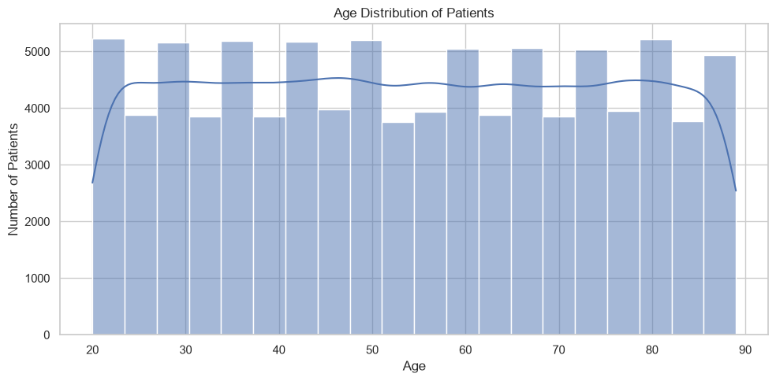

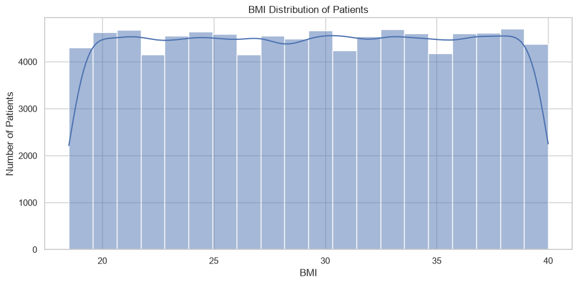

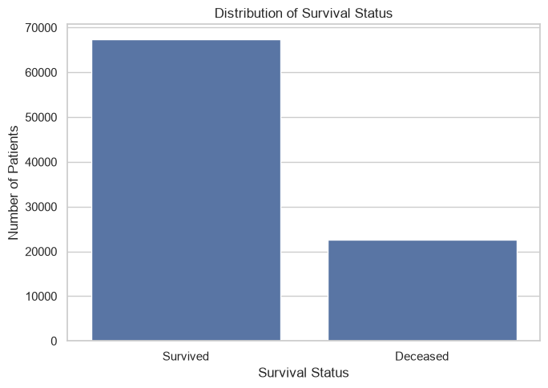

```
Survival Status Counts:
```

```
Survival_Status
Survived    67341
Deceased    22604
Name: count, dtype: int64
```

```
Survival Status Percentages:
```

```
Survival_Status
Survived    74.87
Deceased    25.13
Name: proportion, dtype: float64
```

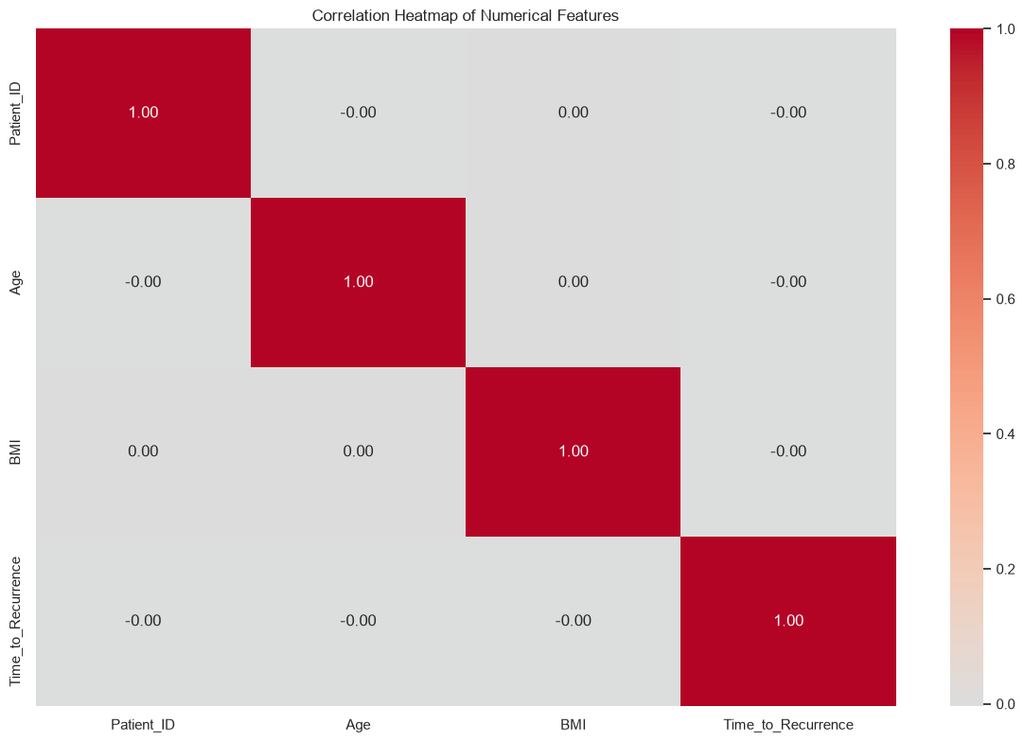

```python
# Distribution of Age

plt.figure(figsize=(10, 5))

sns.histplot(
    data=analysis_df,
    x="Age",
    bins=20,
    kde=True
)

plt.title("Age Distribution of Patients")
plt.xlabel("Age")
plt.ylabel("Number of Patients")
plt.tight_layout()
plt.show()

# Distribution of BMI

plt.figure(figsize=(10, 5))

sns.histplot(
    data=analysis_df,
    x="BMI",
    bins=20,
    kde=True
)

plt.title("BMI Distribution of Patients")
plt.xlabel("BMI")
plt.ylabel("Number of Patients")
plt.tight_layout()
plt.show()


# Survival status distribution

plt.figure(figsize=(7, 5))

sns.countplot(
    data=analysis_df,
    x="Survival_Status"
)

plt.title("Distribution of Survival Status")
plt.xlabel("Survival Status")
plt.ylabel("Number of Patients")
plt.tight_layout()
plt.show()

print("\nSurvival Status Counts:")
display(analysis_df["Survival_Status"].value_counts())

print("\nSurvival Status Percentages:")
display(
    analysis_df["Survival_Status"]
    .value_counts(normalize=True)
    .mul(100)
    .round(2)
)

# Correlation heatmap (numerical features only)

numerical_cols = df.select_dtypes(include=np.number).columns

correlation_matrix = df[numerical_cols].corr()

plt.figure(figsize=(12, 8))

sns.heatmap(
    correlation_matrix,
    annot=True,
    cmap="coolwarm",
    fmt=".2f",
    center=0
)

plt.title("Correlation Heatmap of Numerical Features")
plt.tight_layout()
plt.show()
```

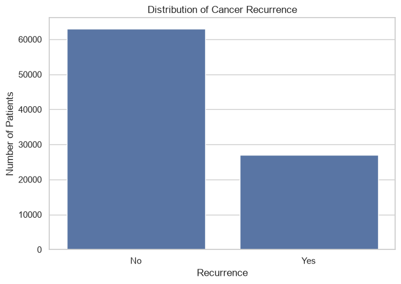

```
Recurrence Counts:
```

```
Recurrence
No     62975
Yes    26970
Name: count, dtype: int64
```

```
Recurrence Percentages:
```

```
Recurrence
No     70.02
Yes    29.98
Name: proportion, dtype: float64
```

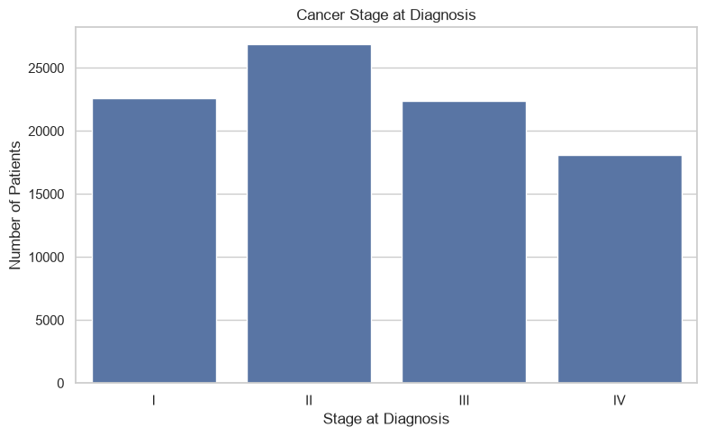

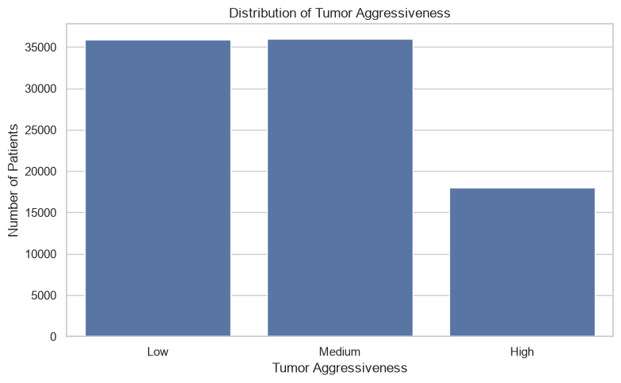

```python
# Recurrence distribution

plt.figure(figsize=(7, 5))

sns.countplot(
    data=analysis_df,
    x="Recurrence"
)

plt.title("Distribution of Cancer Recurrence")
plt.xlabel("Recurrence")
plt.ylabel("Number of Patients")
plt.tight_layout()
plt.show()

print("\nRecurrence Counts:")
display(analysis_df["Recurrence"].value_counts())

print("\nRecurrence Percentages:")
display(
    analysis_df["Recurrence"]
    .value_counts(normalize=True)
    .mul(100)
    .round(2)
)

# Cancer stage distribution

stage_order = ["I", "II", "III", "IV"]

plt.figure(figsize=(8, 5))

sns.countplot(
    data=analysis_df,
    x="Stage_at_Diagnosis",
    order=stage_order
)

plt.title("Cancer Stage at Diagnosis")
plt.xlabel("Stage at Diagnosis")
plt.ylabel("Number of Patients")
plt.tight_layout()
plt.show()

# Tumor aggressiveness distribution

plt.figure(figsize=(8, 5))

sns.countplot(
    data=analysis_df,
    x="Tumor_Aggressiveness",
    order=["Low", "Medium", "High"]
)

plt.title("Distribution of Tumor Aggressiveness")
plt.xlabel("Tumor Aggressiveness")
plt.ylabel("Number of Patients")
plt.tight_layout()
plt.show()
```

## 8. Demographic Analysis

This section examines whether survival patterns differ across demographic groups.

The analysis focuses on:

```
Age_Group
<30      12996
30-39    12855
40-49    13127
50-59    12764
60-69    12705
70-79    12845
80+      12653
Name: count, dtype: int64
```

| Survival_Status Gender | Deceased | Survived |
| --- | --- | --- |
| Female | 25.38 | 74.62 |
| Male | 24.93 | 75.07 |

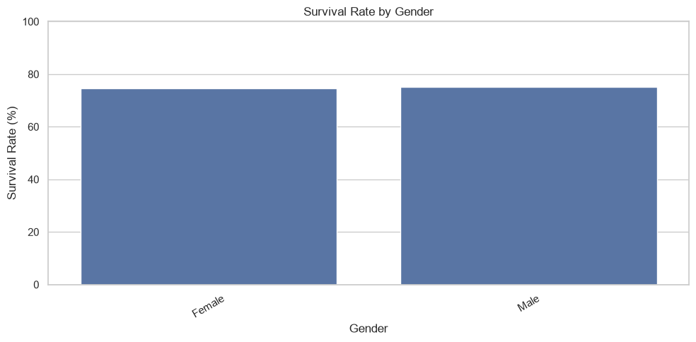

| Survival_Status Age_Group | Deceased | Survived |
| --- | --- | --- |
| <30 | 25.04 | 74.96 |
| 30-39 | 25.47 | 74.53 |
| 40-49 | 25.44 | 74.56 |
| 50-59 | 24.99 | 75.01 |
| 60-69 | 25.28 | 74.72 |
| 70-79 | 24.65 | 75.35 |
| 80+ | 25.05 | 74.95 |

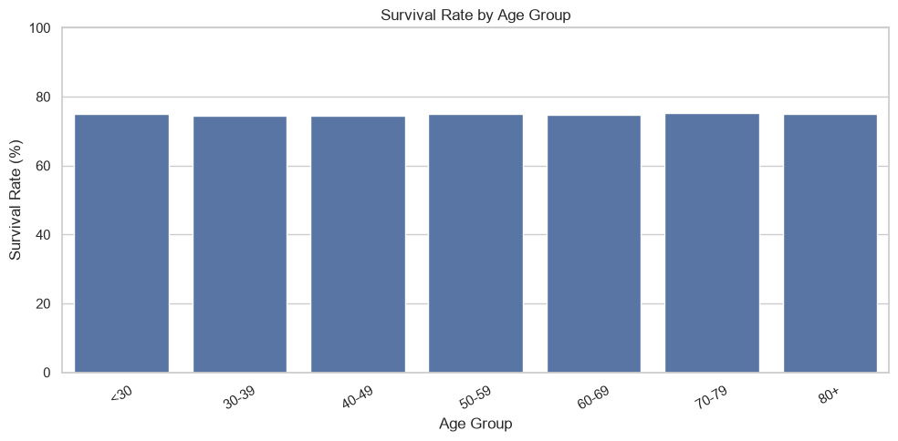

| Survival_Status Age_Group | Deceased | Survived |
| --- | --- | --- |
| <30 | 25.04 | 74.96 |
| 30-39 | 25.47 | 74.53 |
| 40-49 | 25.44 | 74.56 |
| 50-59 | 24.99 | 75.01 |
| 60-69 | 25.28 | 74.72 |
| 70-79 | 24.65 | 75.35 |
| 80+ | 25.05 | 74.95 |

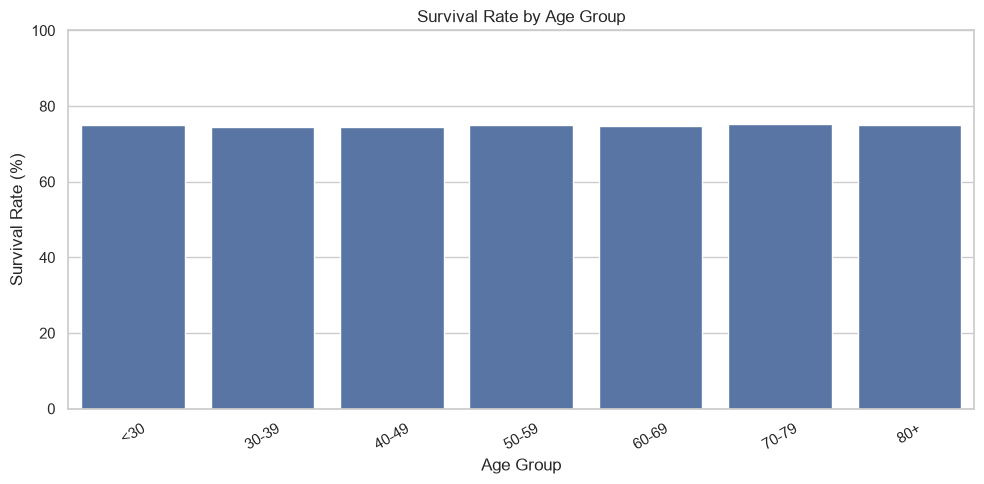

| Survival_Status Socioeconomic_Status | Deceased | Survived |
| --- | --- | --- |
| High | 25.22 | 74.78 |
| Low | 25.44 | 74.56 |
| Middle | 24.91 | 75.09 |

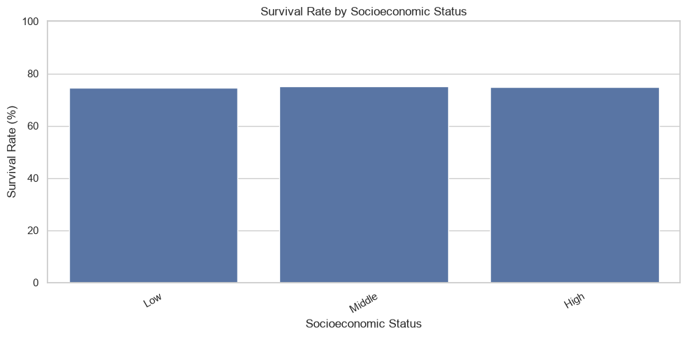

|  | Socioeconomic_Status | Survival_Rate |
| --- | --- | --- |
| 1 | Low | 74.560816 |
| 2 | Middle | 75.088715 |
| 0 | High | 74.779032 |

```python
# Create age groups for comparative analysis

analysis_df["Age_Group"] = pd.cut(
    analysis_df["Age"],
    bins=[0, 29, 39, 49, 59, 69, 79, 100],
    labels=[
        "<30",
        "30-39",
        "40-49",
        "50-59",
        "60-69",
        "70-79",
        "80+"
    ]
)

display(analysis_df["Age_Group"].value_counts().sort_index())

# Helper function for survival-rate analysis

def survival_rate_table(data, column):
    table = pd.crosstab(
        data[column],
        data["Survival_Status"],
        normalize="index"
    ) * 100

    return table.round(2)


def plot_survival_rate(data, column, title, order=None, figsize=(10, 5)):
    survival = (
        data.groupby(column)["Survival_Status"]
        .apply(lambda x: (x == "Survived").mean() * 100)
        .reset_index(name="Survival_Rate")
    )

    if order is not None:
        survival[column] = pd.Categorical(
            survival[column],
            categories=order,
            ordered=True
        )
        survival = survival.sort_values(column)

    plt.figure(figsize=figsize)

    sns.barplot(
        data=survival,
        x=column,
        y="Survival_Rate"
    )

    plt.title(title)
    plt.xlabel(column.replace("_", " "))
    plt.ylabel("Survival Rate (%)")
    plt.xticks(rotation=30)
    plt.ylim(0, 100)
    plt.tight_layout()
    plt.show()

    return survival

# Survival by Gender

display(survival_rate_table(analysis_df, "Gender"))

plot_survival_rate(
    analysis_df,
    "Gender",
    "Survival Rate by Gender"
)

# Survival by Age Group

display(survival_rate_table(analysis_df, "Age_Group"))

plot_survival_rate(
    analysis_df,
    "Age_Group",
    "Survival Rate by Age Group",
    order=["<30", "30-39", "40-49", "50-59", "60-69", "70-79", "80+"],
    figsize=(10, 5)
)

# Survival by Age Group

display(survival_rate_table(analysis_df, "Age_Group"))

plot_survival_rate(
    analysis_df,
    "Age_Group",
    "Survival Rate by Age Group",
    order=["<30", "30-39", "40-49", "50-59", "60-69", "70-79", "80+"],
    figsize=(10, 5)
)

# Survival by socioeconomic status

display(survival_rate_table(analysis_df, "Socioeconomic_Status"))

plot_survival_rate(
    analysis_df,
    "Socioeconomic_Status",
    "Survival Rate by Socioeconomic Status",
    order=["Low", "Middle", "High"]
)
```

## 9. Clinical Analysis

This section examines the relationship between clinical characteristics and survival.

Key variables include:

| Survival_Status Stage_at_Diagnosis | Deceased | Survived |
| --- | --- | --- |
| I | 25.23 | 74.77 |
| II | 25.24 | 74.76 |
| III | 25.00 | 75.00 |
| IV | 25.01 | 74.99 |

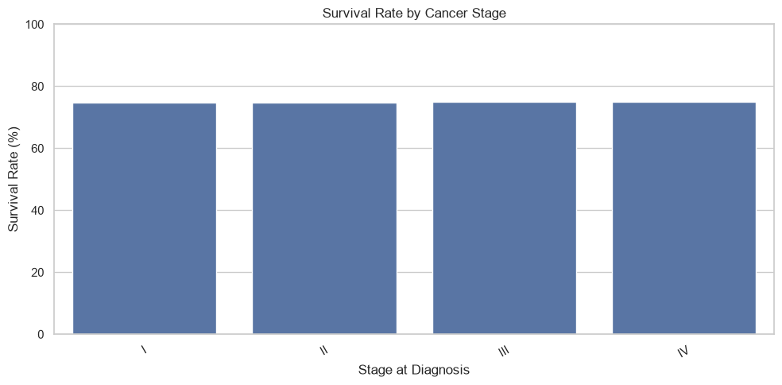

| Survival_Status Tumor_Aggressiveness | Deceased | Survived |
| --- | --- | --- |
| High | 25.35 | 74.65 |
| Low | 25.31 | 74.69 |
| Medium | 24.84 | 75.16 |

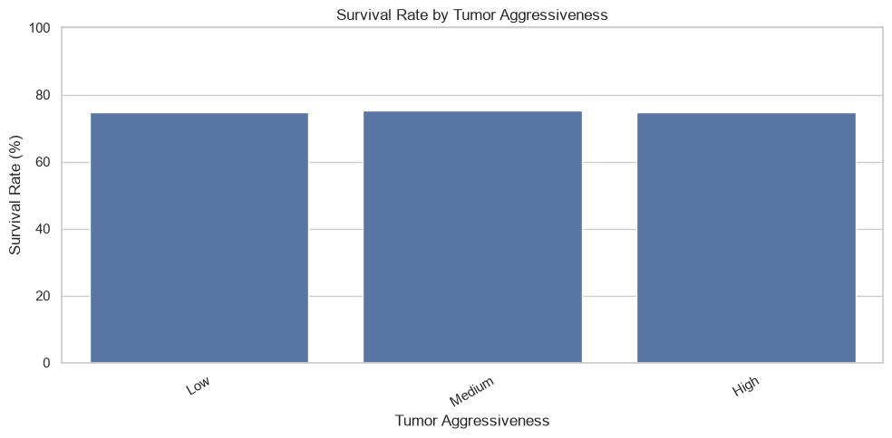

| Survival_Status Time_to_Diagnosis | Deceased | Survived |
| --- | --- | --- |
| Delayed | 25.10 | 74.90 |
| Timely | 25.15 | 74.85 |

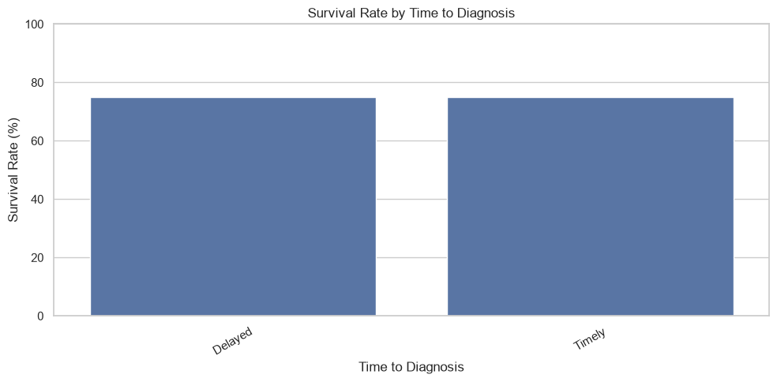

| Survival_Status Previous_Cancer_History | Deceased | Survived |
| --- | --- | --- |
| No | 25.13 | 74.87 |
| Yes | 25.16 | 74.84 |

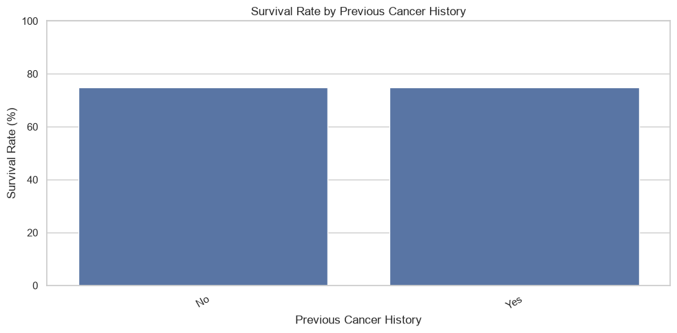

|  | Previous_Cancer_History | Survival_Rate |
| --- | --- | --- |
| 0 | No | 74.87189 |
| 1 | Yes | 74.84375 |

```python
# Survival by cancer stage

stage_survival = survival_rate_table(
    analysis_df,
    "Stage_at_Diagnosis"
)

display(stage_survival)

plot_survival_rate(
    analysis_df,
    "Stage_at_Diagnosis",
    "Survival Rate by Cancer Stage",
    order=["I", "II", "III", "IV"]
)
# Survival by tumor aggressiveness

display(
    survival_rate_table(
        analysis_df,
        "Tumor_Aggressiveness"
    )
)

plot_survival_rate(
    analysis_df,
    "Tumor_Aggressiveness",
    "Survival Rate by Tumor Aggressiveness",
    order=["Low", "Medium", "High"]
)
# Survival by time to diagnosis

display(
    survival_rate_table(
        analysis_df,
        "Time_to_Diagnosis"
    )
)

plot_survival_rate(
    analysis_df,
    "Time_to_Diagnosis",
    "Survival Rate by Time to Diagnosis"
)
# Survival by previous cancer history

display(
    survival_rate_table(
        analysis_df,
        "Previous_Cancer_History"
    )
)

plot_survival_rate(
    analysis_df,
    "Previous_Cancer_History",
    "Survival Rate by Previous Cancer History"
)
```

## 10. Lifestyle and Potential Risk-Factor Analysis

This section explores associations between survival and lifestyle-related variables.

Variables analyzed include:

- Diet type
- Physical activity
- Smoking status
- Alcohol consumption
- Red meat consumption
- Fiber consumption
- BMI

| Survival_Status Diet_Type | Deceased | Survived |
| --- | --- | --- |
| Balanced | 24.83 | 75.17 |
| Traditional | 24.98 | 75.02 |
| Western | 25.37 | 74.63 |

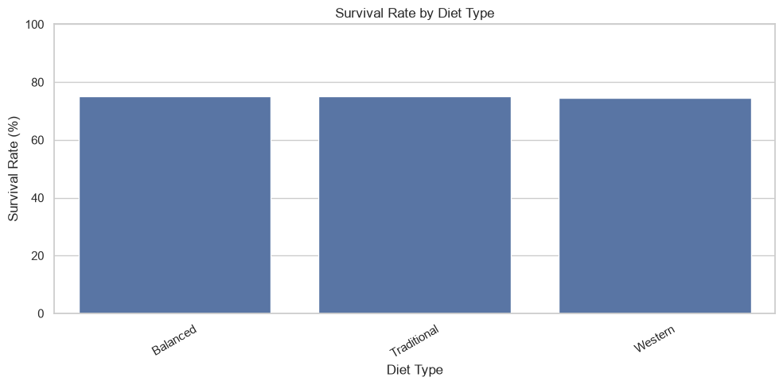

| Survival_Status Physical_Activity_Level | Deceased | Survived |
| --- | --- | --- |
| High | 25.11 | 74.89 |
| Low | 25.12 | 74.88 |
| Medium | 25.16 | 74.84 |

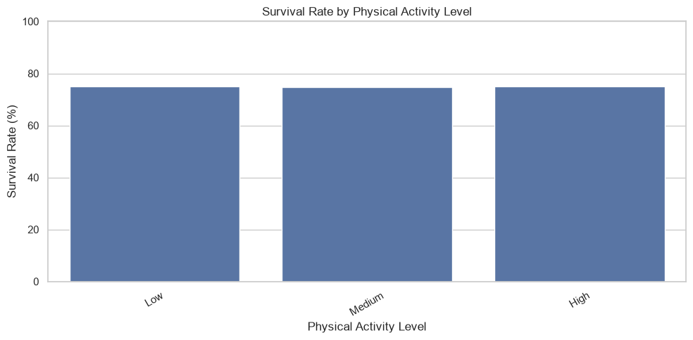

| Survival_Status Smoking_Status | Deceased | Survived |
| --- | --- | --- |
| Current | 25.08 | 74.92 |
| Former | 25.38 | 74.62 |
| Never | 25.01 | 74.99 |

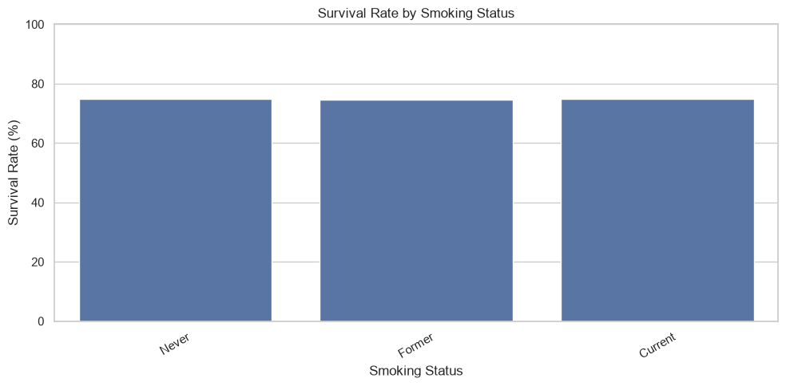

| Survival_Status Alcohol_Consumption | Deceased | Survived |
| --- | --- | --- |
| High | 25.37 | 74.63 |
| Low | 25.06 | 74.94 |
| Medium | 25.09 | 74.91 |

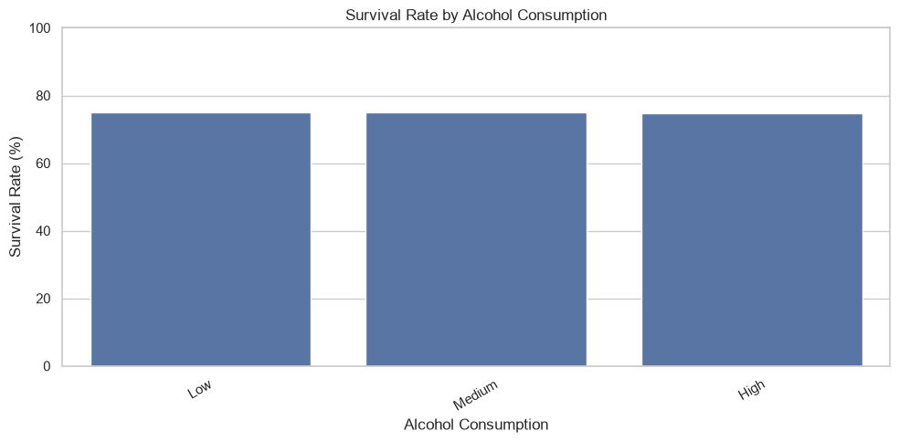

| Survival_Status Red_Meat_Consumption | Deceased | Survived |
| --- | --- | --- |
| High | 25.20 | 74.80 |
| Low | 24.87 | 75.13 |
| Medium | 25.36 | 74.64 |

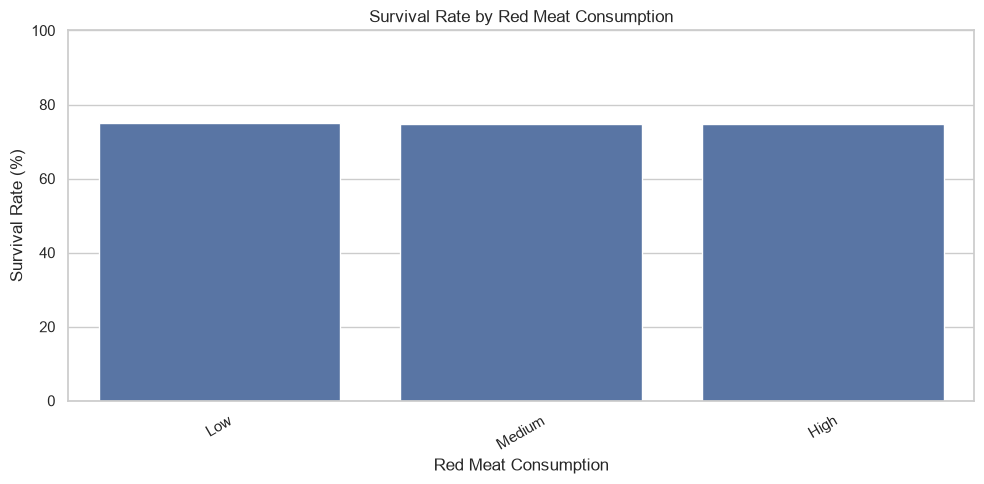

| Survival_Status Fiber_Consumption | Deceased | Survived |
| --- | --- | --- |
| High | 25.18 | 74.82 |
| Low | 24.80 | 75.20 |
| Medium | 25.31 | 74.69 |

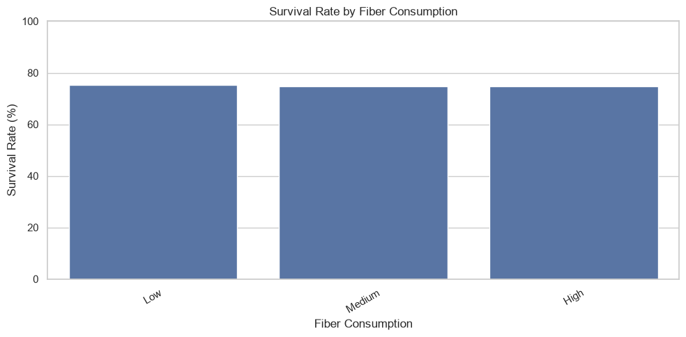

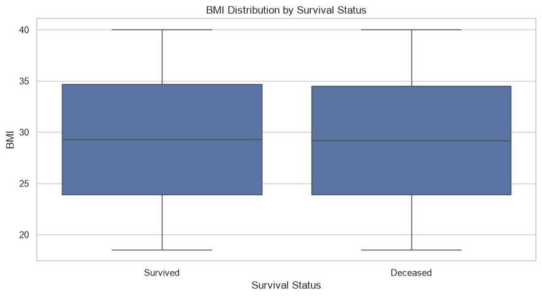

```python
# Survival by diet type

display(survival_rate_table(analysis_df, "Diet_Type"))

plot_survival_rate(
    analysis_df,
    "Diet_Type",
    "Survival Rate by Diet Type"
)
# Survival by physical activity level

display(
    survival_rate_table(
        analysis_df,
        "Physical_Activity_Level"
    )
)

plot_survival_rate(
    analysis_df,
    "Physical_Activity_Level",
    "Survival Rate by Physical Activity Level",
    order=["Low", "Medium", "High"]
)
# Survival by smoking status

display(
    survival_rate_table(
        analysis_df,
        "Smoking_Status"
    )
)

plot_survival_rate(
    analysis_df,
    "Smoking_Status",
    "Survival Rate by Smoking Status",
    order=["Never", "Former", "Current"]
)

# Survival by alcohol consumption

display(
    survival_rate_table(
        analysis_df,
        "Alcohol_Consumption"
    )
)

plot_survival_rate(
    analysis_df,
    "Alcohol_Consumption",
    "Survival Rate by Alcohol Consumption",
    order=["Low", "Medium", "High"]
)
# Survival by red meat consumption

display(
    survival_rate_table(
        analysis_df,
        "Red_Meat_Consumption"
    )
)

plot_survival_rate(
    analysis_df,
    "Red_Meat_Consumption",
    "Survival Rate by Red Meat Consumption",
    order=["Low", "Medium", "High"]
)
# Survival by fiber consumption

display(
    survival_rate_table(
        analysis_df,
        "Fiber_Consumption"
    )
)

plot_survival_rate(
    analysis_df,
    "Fiber_Consumption",
    "Survival Rate by Fiber Consumption",
    order=["Low", "Medium", "High"]
)
# BMI distribution by survival status

plt.figure(figsize=(9, 5))

sns.boxplot(
    data=analysis_df,
    x="Survival_Status",
    y="BMI"
)

plt.title("BMI Distribution by Survival Status")
plt.xlabel("Survival Status")
plt.ylabel("BMI")
plt.tight_layout()
plt.show()
```

## 11. Healthcare Access and Treatment Analysis

This section investigates how healthcare access and treatment-related variables are associated with survival.

Variables include:

- Colonoscopy access
- Screening regularity
- Insurance coverage
- Treatment access
- Chemotherapy
- Radiotherapy
- Surgery
- Follow-up adherence

These comparisons show associations in the dataset and should not be interpreted as evidence that a particular treatment directly causes better or worse survival.

```
============================================================
Colonoscopy_Access
============================================================
```

| Survival_Status Colonoscopy_Access | Deceased | Survived |
| --- | --- | --- |
| No | 24.96 | 75.04 |
| Yes | 25.19 | 74.81 |

```
============================================================
Screening_Regularity
============================================================
```

| Survival_Status Screening_Regularity | Deceased | Survived |
| --- | --- | --- |
| Irregular | 24.85 | 75.15 |
| Never | 25.18 | 74.82 |
| Regular | 25.28 | 74.72 |

```
============================================================
Insurance_Coverage
============================================================
```

| Survival_Status Insurance_Coverage | Deceased | Survived |
| --- | --- | --- |
| No | 25.42 | 74.58 |
| Yes | 25.06 | 74.94 |

```
============================================================
Treatment_Access
============================================================
```

| Survival_Status Treatment_Access | Deceased | Survived |
| --- | --- | --- |
| Good | 25.21 | 74.79 |
| Limited | 24.94 | 75.06 |

```
============================================================
Chemotherapy_Received
============================================================
```

| Survival_Status Chemotherapy_Received | Deceased | Survived |
| --- | --- | --- |
| No | 25.00 | 75.00 |
| Yes | 25.26 | 74.74 |

```
============================================================
Radiotherapy_Received
============================================================
```

| Survival_Status Radiotherapy_Received | Deceased | Survived |
| --- | --- | --- |
| No | 24.89 | 75.11 |
| Yes | 25.49 | 74.51 |

```
============================================================
Surgery_Received
============================================================
```

| Survival_Status Surgery_Received | Deceased | Survived |
| --- | --- | --- |
| No | 25.52 | 74.48 |
| Yes | 24.97 | 75.03 |

```
============================================================
Follow_Up_Adherence
============================================================
```

| Survival_Status Follow_Up_Adherence | Deceased | Survived |
| --- | --- | --- |
| Good | 25.29 | 74.71 |
| Poor | 24.89 | 75.11 |

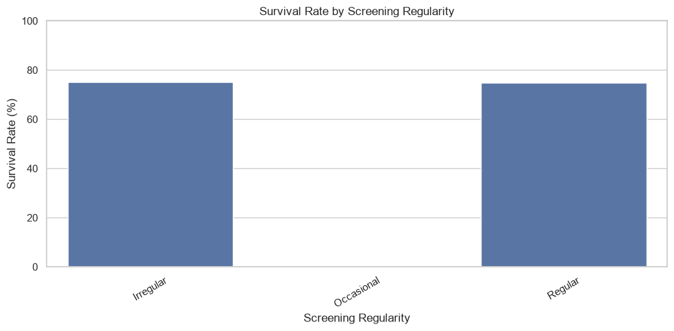

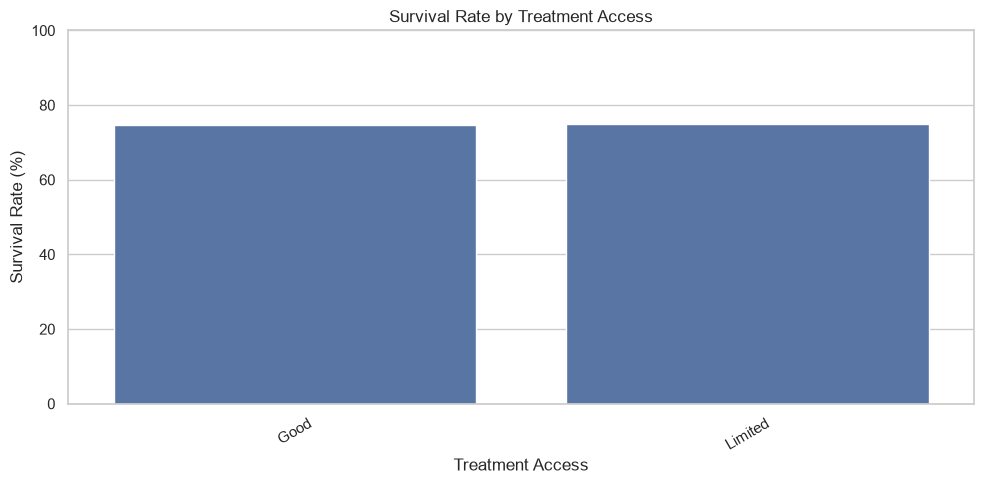

|  | Received | Survival_Rate | Treatment |
| --- | --- | --- | --- |
| 0 | No | 75.003342 | Chemotherapy |
| 1 | Yes | 74.735394 | Chemotherapy |
| 2 | No | 75.107503 | Radiotherapy |
| 3 | Yes | 74.511711 | Radiotherapy |
| 4 | No | 74.484593 | Surgery |
| 5 | Yes | 75.034590 | Surgery |

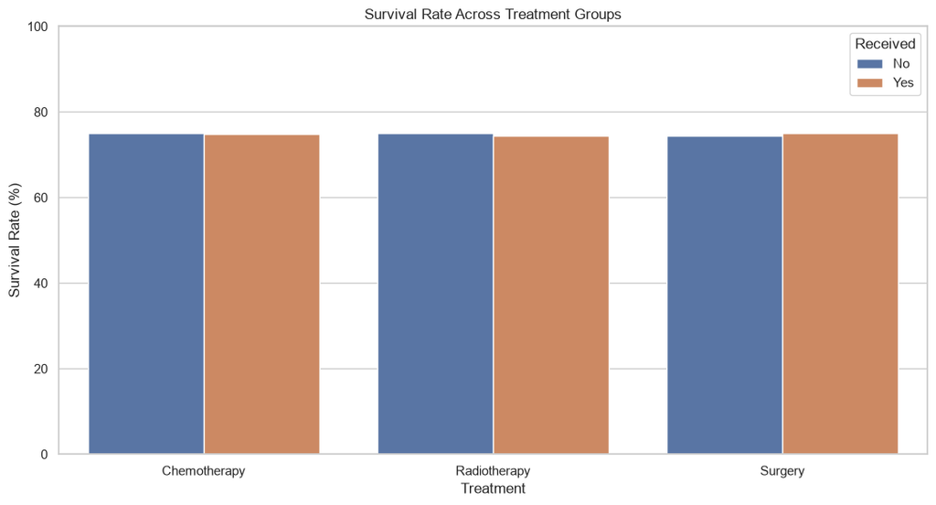

```python
# Healthcare access variables

healthcare_columns = [
    "Colonoscopy_Access",
    "Screening_Regularity",
    "Insurance_Coverage",
    "Treatment_Access",
    "Chemotherapy_Received",
    "Radiotherapy_Received",
    "Surgery_Received",
    "Follow_Up_Adherence"
]

for column in healthcare_columns:
    print(f"\n{'=' * 60}")
    print(column)
    print("=" * 60)

    display(survival_rate_table(analysis_df, column))
    # Survival by screening regularity

plot_survival_rate(
    analysis_df,
    "Screening_Regularity",
    "Survival Rate by Screening Regularity",
    order=["Irregular", "Occasional", "Regular"]
)
# Survival by treatment access

plot_survival_rate(
    analysis_df,
    "Treatment_Access",
    "Survival Rate by Treatment Access"
)
# Compare survival across treatment types

treatment_columns = [
    "Chemotherapy_Received",
    "Radiotherapy_Received",
    "Surgery_Received"
]

treatment_results = []

for column in treatment_columns:
    temp = (
        analysis_df.groupby(column)["Survival_Status"]
        .apply(lambda x: (x == "Survived").mean() * 100)
        .reset_index(name="Survival_Rate")
    )

    temp["Treatment"] = column.replace("_Received", "")
    temp = temp.rename(columns={column: "Received"})

    treatment_results.append(temp)

treatment_survival = pd.concat(
    treatment_results,
    ignore_index=True
)

display(treatment_survival)

plt.figure(figsize=(11, 6))

sns.barplot(
    data=treatment_survival,
    x="Treatment",
    y="Survival_Rate",
    hue="Received"
)

plt.title("Survival Rate Across Treatment Groups")
plt.xlabel("Treatment")
plt.ylabel("Survival Rate (%)")
plt.ylim(0, 100)
plt.tight_layout()
plt.show()
```

## 12. Recurrence Analysis

Recurrence is analyzed separately because `Time_to_Recurrence` is most meaningful for patients who experienced recurrence.

The analysis will examine:

```
Recurrence
No     70.02
Yes    29.98
Name: proportion, dtype: float64
```

```
Overall recurrence rate: 29.98%
Number of patients with recurrence: 26970
```

```
count    26970.000000
mean        29.629848
std         17.239742
min          0.000000
25%         15.000000
50%         30.000000
75%         45.000000
max         59.000000
Name: Time_to_Recurrence, dtype: float64
```

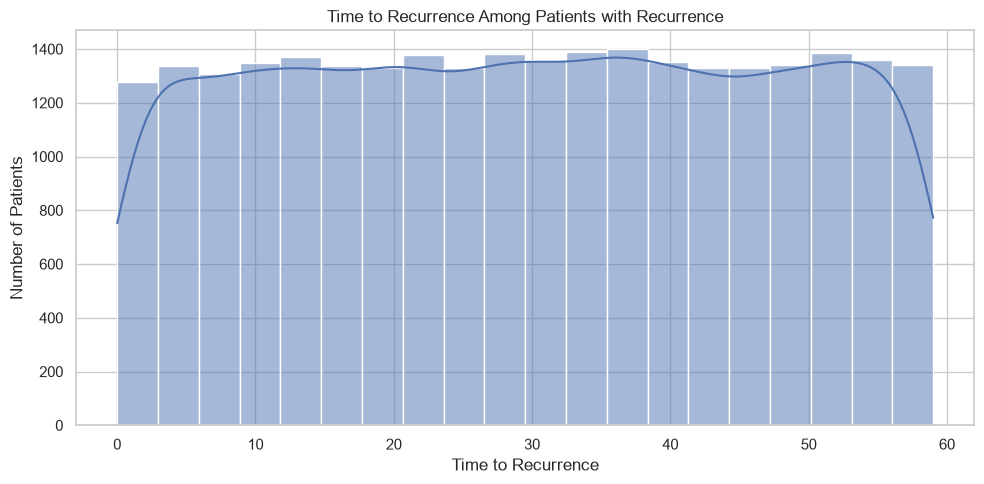

|  | Stage_at_Diagnosis | Recurrence_Rate |
| --- | --- | --- |
| 0 | I | 29.928300 |
| 1 | II | 29.718263 |
| 2 | III | 30.327503 |
| 3 | IV | 30.027670 |

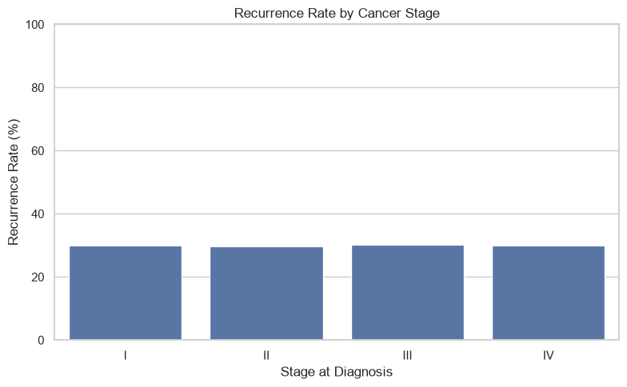

|  | Tumor_Aggressiveness | Recurrence_Rate |
| --- | --- | --- |
| 1 | Low | 29.748685 |
| 2 | Medium | 29.907711 |
| 0 | High | 30.609756 |

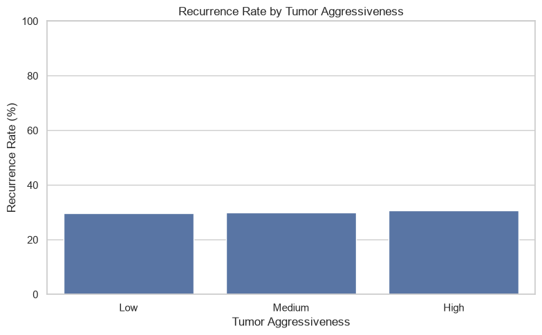

```python
# Recurrence rate

recurrence_rate = (
    analysis_df["Recurrence"]
    .value_counts(normalize=True)
    .mul(100)
    .round(2)
)

display(recurrence_rate)

print(
    f"Overall recurrence rate: "
    f"{(analysis_df['Recurrence'] == 'Yes').mean() * 100:.2f}%"
)
# Time to recurrence among patients with recurrence

recurrence_df = analysis_df[
    analysis_df["Recurrence"] == "Yes"
].copy()

print(
    "Number of patients with recurrence:",
    len(recurrence_df)
)

display(
    recurrence_df["Time_to_Recurrence"]
    .describe()
)

# Distribution of time to recurrence

plt.figure(figsize=(10, 5))

sns.histplot(
    data=recurrence_df,
    x="Time_to_Recurrence",
    bins=20,
    kde=True
)

plt.title("Time to Recurrence Among Patients with Recurrence")
plt.xlabel("Time to Recurrence")
plt.ylabel("Number of Patients")
plt.tight_layout()
plt.show()

# Recurrence rate by cancer stage

recurrence_by_stage = (
    analysis_df.groupby("Stage_at_Diagnosis")["Recurrence"]
    .apply(lambda x: (x == "Yes").mean() * 100)
    .reset_index(name="Recurrence_Rate")
)

recurrence_by_stage["Stage_at_Diagnosis"] = pd.Categorical(
    recurrence_by_stage["Stage_at_Diagnosis"],
    categories=["I", "II", "III", "IV"],
    ordered=True
)

recurrence_by_stage = recurrence_by_stage.sort_values(
    "Stage_at_Diagnosis"
)

display(recurrence_by_stage)

plt.figure(figsize=(8, 5))

sns.barplot(
    data=recurrence_by_stage,
    x="Stage_at_Diagnosis",
    y="Recurrence_Rate"
)

plt.title("Recurrence Rate by Cancer Stage")
plt.xlabel("Stage at Diagnosis")
plt.ylabel("Recurrence Rate (%)")
plt.ylim(0, 100)
plt.tight_layout()
plt.show()

# Recurrence rate by tumor aggressiveness

recurrence_by_aggressiveness = (
    analysis_df.groupby("Tumor_Aggressiveness")["Recurrence"]
    .apply(lambda x: (x == "Yes").mean() * 100)
    .reset_index(name="Recurrence_Rate")
)

recurrence_by_aggressiveness["Tumor_Aggressiveness"] = pd.Categorical(
    recurrence_by_aggressiveness["Tumor_Aggressiveness"],
    categories=["Low", "Medium", "High"],
    ordered=True
)

recurrence_by_aggressiveness = recurrence_by_aggressiveness.sort_values(
    "Tumor_Aggressiveness"
)

display(recurrence_by_aggressiveness)

plt.figure(figsize=(8, 5))

sns.barplot(
    data=recurrence_by_aggressiveness,
    x="Tumor_Aggressiveness",
    y="Recurrence_Rate"
)

plt.title("Recurrence Rate by Tumor Aggressiveness")
plt.xlabel("Tumor Aggressiveness")
plt.ylabel("Recurrence Rate (%)")
plt.ylim(0, 100)
plt.tight_layout()
plt.show()
```

## 13. Correlation Analysis

Correlation analysis is performed for numerical variables only.

The numerical variables in this dataset include:

- Age
- BMI
- Time to Recurrence

Because categorical variables represent groups rather than continuous numerical measurements, they are not included in the standard Pearson correlation heatmap.

|  | Age | BMI | Time_to_Recurrence |
| --- | --- | --- | --- |
| Age | 1.0 | 0.0 | -0.0 |
| BMI | 0.0 | 1.0 | -0.0 |
| Time_to_Recurrence | -0.0 | -0.0 | 1.0 |

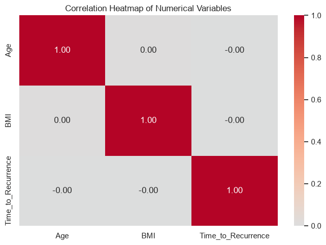

```python
# Correlation heatmap for numerical variables

numerical_analysis_columns = [
    "Age",
    "BMI",
    "Time_to_Recurrence"
]

correlation_matrix = analysis_df[
    numerical_analysis_columns
].corr()

display(correlation_matrix.round(2))

plt.figure(figsize=(7, 5))

sns.heatmap(
    correlation_matrix,
    annot=True,
    cmap="coolwarm",
    fmt=".2f",
    center=0
)

plt.title("Correlation Heatmap of Numerical Variables")
plt.tight_layout()
plt.show()
```

## 14. Multivariable Comparative Analysis

This section combines selected clinical variables to examine survival patterns across multiple groups.

The analysis focuses on:

- Cancer stage
- Tumor aggressiveness
- Survival status

|  | Stage_at_Diagnosis | Tumor_Aggressiveness | Survival_Rate |
| --- | --- | --- | --- |
| 0 | I | High | 74.499450 |
| 1 | I | Low | 74.262023 |
| 2 | I | Medium | 75.422035 |
| 3 | II | High | 74.732374 |
| 4 | II | Low | 75.112066 |
| 5 | II | Medium | 74.420553 |
| 6 | III | High | 74.983292 |
| 7 | III | Low | 74.282203 |
| 8 | III | Medium | 75.724476 |
| 9 | IV | High | 74.303233 |
| 10 | IV | Low | 75.093400 |
| 11 | IV | Medium | 75.230875 |

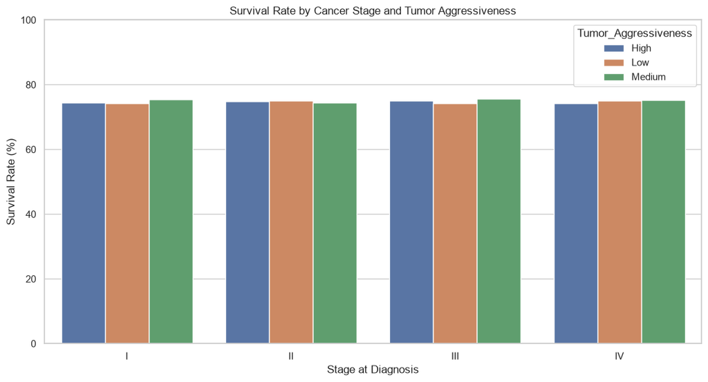

```python
# Survival rate by cancer stage and tumor aggressiveness

combined_survival = (
    analysis_df
    .groupby(
        ["Stage_at_Diagnosis", "Tumor_Aggressiveness"]
    )["Survival_Status"]
    .apply(lambda x: (x == "Survived").mean() * 100)
    .reset_index(name="Survival_Rate")
)

combined_survival["Stage_at_Diagnosis"] = pd.Categorical(
    combined_survival["Stage_at_Diagnosis"],
    categories=["I", "II", "III", "IV"],
    ordered=True
)

combined_survival = combined_survival.sort_values(
    "Stage_at_Diagnosis"
)

display(combined_survival)

plt.figure(figsize=(11, 6))

sns.barplot(
    data=combined_survival,
    x="Stage_at_Diagnosis",
    y="Survival_Rate",
    hue="Tumor_Aggressiveness"
)

plt.title(
    "Survival Rate by Cancer Stage and Tumor Aggressiveness"
)

plt.xlabel("Stage at Diagnosis")
plt.ylabel("Survival Rate (%)")
plt.ylim(0, 100)
plt.tight_layout()
plt.show()
```

## 15. Key Findings

When interpreting the results, the analysis focuses on associations observed in the dataset rather than causal relationships.

Key areas to evaluate include:

- Which age groups show different survival patterns?
- How does survival vary across cancer stages?
- Is tumor aggressiveness associated with survival?
- Which lifestyle variables show noticeable differences in survival rates?
- How do screening and healthcare access relate to survival?
- How does follow-up adherence relate to survival?
- How does recurrence vary across cancer stages and tumor aggressiveness?
- Which numerical variables show meaningful correlations?

```python
# Generate a compact summary of important survival rates

summary_factors = [
    "Gender",
    "Age_Group",
    "Stage_at_Diagnosis",
    "Tumor_Aggressiveness",
    "Smoking_Status",
    "Physical_Activity_Level",
    "Screening_Regularity",
    "Treatment_Access",
    "Follow_Up_Adherence"
]

summary_results = []

for column in summary_factors:
    result = (
        analysis_df.groupby(column)["Survival_Status"]
        .apply(lambda x: (x == "Survived").mean() * 100)
        .reset_index(name="Survival_Rate")
    )

    result["Factor"] = column

    summary_results.append(result)

survival_summary = pd.concat(
    summary_results,
    ignore_index=True
)

survival_summary["Survival_Rate"] = (
    survival_summary["Survival_Rate"].round(2)
)

display(survival_summary)
```

|  | Gender | Survival_Rate | Factor | Age_Group | Stage_at_Diagnosis | Tumor_Aggressiveness | Smoking_Status | Physical_Activity_Level | Screening_Regularity | Treatment_Access | Follow_Up_Adherence |
| --- | --- | --- | --- | --- | --- | --- | --- | --- | --- | --- | --- |
| 0 | Female | 74.62 | Gender | NaN | NaN | NaN | NaN | NaN | NaN | NaN | NaN |
| 1 | Male | 75.07 | Gender | NaN | NaN | NaN | NaN | NaN | NaN | NaN | NaN |
| 2 | NaN | 74.96 | Age_Group | <30 | NaN | NaN | NaN | NaN | NaN | NaN | NaN |
| 3 | NaN | 74.53 | Age_Group | 30-39 | NaN | NaN | NaN | NaN | NaN | NaN | NaN |
| 4 | NaN | 74.56 | Age_Group | 40-49 | NaN | NaN | NaN | NaN | NaN | NaN | NaN |
| 5 | NaN | 75.01 | Age_Group | 50-59 | NaN | NaN | NaN | NaN | NaN | NaN | NaN |
| 6 | NaN | 74.72 | Age_Group | 60-69 | NaN | NaN | NaN | NaN | NaN | NaN | NaN |
| 7 | NaN | 75.35 | Age_Group | 70-79 | NaN | NaN | NaN | NaN | NaN | NaN | NaN |
| 8 | NaN | 74.95 | Age_Group | 80+ | NaN | NaN | NaN | NaN | NaN | NaN | NaN |
| 9 | NaN | 74.77 | Stage_at_Diagnosis | NaN | I | NaN | NaN | NaN | NaN | NaN | NaN |
| 10 | NaN | 74.76 | Stage_at_Diagnosis | NaN | II | NaN | NaN | NaN | NaN | NaN | NaN |
| 11 | NaN | 75.00 | Stage_at_Diagnosis | NaN | III | NaN | NaN | NaN | NaN | NaN | NaN |
| 12 | NaN | 74.99 | Stage_at_Diagnosis | NaN | IV | NaN | NaN | NaN | NaN | NaN | NaN |
| 13 | NaN | 74.65 | Tumor_Aggressiveness | NaN | NaN | High | NaN | NaN | NaN | NaN | NaN |
| 14 | NaN | 74.69 | Tumor_Aggressiveness | NaN | NaN | Low | NaN | NaN | NaN | NaN | NaN |
| 15 | NaN | 75.16 | Tumor_Aggressiveness | NaN | NaN | Medium | NaN | NaN | NaN | NaN | NaN |
| 16 | NaN | 74.92 | Smoking_Status | NaN | NaN | NaN | Current | NaN | NaN | NaN | NaN |
| 17 | NaN | 74.62 | Smoking_Status | NaN | NaN | NaN | Former | NaN | NaN | NaN | NaN |
| 18 | NaN | 74.99 | Smoking_Status | NaN | NaN | NaN | Never | NaN | NaN | NaN | NaN |
| 19 | NaN | 74.89 | Physical_Activity_Level | NaN | NaN | NaN | NaN | High | NaN | NaN | NaN |
| 20 | NaN | 74.88 | Physical_Activity_Level | NaN | NaN | NaN | NaN | Low | NaN | NaN | NaN |
| 21 | NaN | 74.84 | Physical_Activity_Level | NaN | NaN | NaN | NaN | Medium | NaN | NaN | NaN |
| 22 | NaN | 75.15 | Screening_Regularity | NaN | NaN | NaN | NaN | NaN | Irregular | NaN | NaN |
| 23 | NaN | 74.82 | Screening_Regularity | NaN | NaN | NaN | NaN | NaN | Never | NaN | NaN |
| 24 | NaN | 74.72 | Screening_Regularity | NaN | NaN | NaN | NaN | NaN | Regular | NaN | NaN |
| 25 | NaN | 74.79 | Treatment_Access | NaN | NaN | NaN | NaN | NaN | NaN | Good | NaN |
| 26 | NaN | 75.06 | Treatment_Access | NaN | NaN | NaN | NaN | NaN | NaN | Limited | NaN |
| 27 | NaN | 74.71 | Follow_Up_Adherence | NaN | NaN | NaN | NaN | NaN | NaN | NaN | Good |
| 28 | NaN | 75.11 | Follow_Up_Adherence | NaN | NaN | NaN | NaN | NaN | NaN | NaN | Poor |

## 16. Conclusion

This exploratory data analysis provided an overview of colorectal cancer patient characteristics and examined patterns associated with survival and recurrence.

The analysis covered demographic characteristics, lifestyle factors, clinical characteristics, healthcare access, treatment-related variables, and recurrence.

### Important Interpretation

These findings represent associations observed in the available data. They should not be interpreted as proof of causation, medical recommendations, or individual patient predictions.

### Project Outcome

The project demonstrates practical data analyst skills including:

- Data loading and inspection
- Data quality assessment
- Missing-value analysis
- Duplicate detection
- Descriptive statistics
- Data visualization
- Group-wise analysis
- Survival-rate analysis
- Recurrence analysis
- Correlation analysis
- Insight generation

## 17. Final Takeaways

### Data Quality

- The dataset contains 89,945 patient records and 30 variables.
- Missing values and duplicate records were assessed before analysis.
- Patient ID was excluded from analytical comparisons because it is an identifier.

### Exploratory Analysis

- Demographic, lifestyle, clinical, healthcare, treatment, survival, and recurrence variables were explored.
- Numerical distributions were examined using histograms and boxplots.
- Categorical variables were analyzed using counts and survival-rate comparisons.

### Clinical Insights

- Cancer stage and tumor aggressiveness were examined in relation to survival.
- Recurrence patterns were compared across cancer stages and tumor aggressiveness.

### Healthcare Insights

- Screening, healthcare access, treatment access, and follow-up adherence were compared with survival outcomes.

### Analytical Limitation

The dataset is observational. Differences between groups may be influenced by multiple factors, so the results should be interpreted as descriptive associations rather than causal effects.